# oblig6

Harald Groven

10/29/2018

## Create tribble `DS` with 6 variables

```r
DS = tribble(
 ~fk_account_code, ~Ansvar, ~fk_function_code, ~fk_project_code, ~amount,
 101030, 40220, "Det", 3432, 1493.00,
 101030, 40220, "Met", 3586, 2827.00,
 101030, 40320, "Det", 3456, 49440.00,
 101030, 40330, "Sal", NA, 870716.00,
 101030, 40350, "Met", NA, 559928.00,
 101030, 40360, "Sal", NA, 125534.00,
 101030, 40280, "Pol", NA, 251611.00
 )
# View(DS)
```

## Drop a variable

1. Remove the `fk_project_code` variable from `DS`.

In tidyr this may be achieved by selecting the data frame minus the unwanted columnt. This has the same effect as dropping the variable.

```r
DS <- select(DS, -fk_project_code)
```

2. Sum the `amount` by the 3 first digits of `Ansvar`; 402, 403, etc.

Created new variable `ansvar3` containing the 3 first digits of Ansvar by using the regular expression `\\d{3,3}` This new variable could then be used for grouping and summarising.

```r
DS %>%
  mutate(ansvar3 = str_extract(DS$Ansvar, "\\d{3,3}")) %>%
  select(ansvar3, amount) %>%
  group_by(ansvar3) %>%
  summarise(sum = sum(amount)) %>%
  # style
  kable() %>%
  kable_styling()
```

| ansvar3 | sum |
| --- | --- |
| 402 | 255931 |
| 403 | 1605618 |

## Recode values

3. Make new “labels” for `fk_function_code`, where: `Det` and `Sal` is `supplies`, `Met` is `inventories` and `Pol` is `other expenses`

Created a new variable `fk_function_label` as a copy of `fk_function_code`. Then used the `recode` function to replace codes with readable labels.

```r
DS <- DS %>%
  mutate(fk_function_label = recode(DS$fk_function_code,
       "Det" = "supplies",
       "Sal" = "supplies",
       "Met" = "inventories",
       "Pol" = "other expenses"
       ))
# View(DS)
```

## Sum and group by

Calculate the share of sales per product per year. The sum over the 3 shares per year is 100.

```r
# first read some toy data
df <- data.frame(Product=gl(3,10,labels=c("A", "B", "C")),
                Year=factor(rep(2002:2011, 3)),
                Sales=1:30)
# View(df)

df <- df %>%
  group_by(Year) %>%
  mutate(sum_year = sum(Sales)) %>%
  ungroup() %>%
  mutate(pst_sum_year = (100/sum_year)*Sales)

df %>%
  # style
  kable() %>%
  kable_styling()
```

| Product | Year | Sales | sum_year | pst_sum_year |
| --- | --- | --- | --- | --- |
| A | 2002 | 1 | 33 | 3.030303 |
| A | 2003 | 2 | 36 | 5.555556 |
| A | 2004 | 3 | 39 | 7.692308 |
| A | 2005 | 4 | 42 | 9.523810 |
| A | 2006 | 5 | 45 | 11.111111 |
| A | 2007 | 6 | 48 | 12.500000 |
| A | 2008 | 7 | 51 | 13.725490 |
| A | 2009 | 8 | 54 | 14.814815 |
| A | 2010 | 9 | 57 | 15.789474 |
| A | 2011 | 10 | 60 | 16.666667 |
| B | 2002 | 11 | 33 | 33.333333 |
| B | 2003 | 12 | 36 | 33.333333 |
| B | 2004 | 13 | 39 | 33.333333 |
| B | 2005 | 14 | 42 | 33.333333 |
| B | 2006 | 15 | 45 | 33.333333 |
| B | 2007 | 16 | 48 | 33.333333 |
| B | 2008 | 17 | 51 | 33.333333 |
| B | 2009 | 18 | 54 | 33.333333 |
| B | 2010 | 19 | 57 | 33.333333 |
| B | 2011 | 20 | 60 | 33.333333 |
| C | 2002 | 21 | 33 | 63.636364 |
| C | 2003 | 22 | 36 | 61.111111 |
| C | 2004 | 23 | 39 | 58.974359 |
| C | 2005 | 24 | 42 | 57.142857 |
| C | 2006 | 25 | 45 | 55.555556 |
| C | 2007 | 26 | 48 | 54.166667 |
| C | 2008 | 27 | 51 | 52.941176 |
| C | 2009 | 28 | 54 | 51.851852 |
| C | 2010 | 29 | 57 | 50.877193 |
| C | 2011 | 30 | 60 | 50.000000 |

## Stacked bar chart

Make a plot of the sales and shares per year per company.

Easiest possible stacked bar chart may be created with `ggplot2`’s `geom_bar`. Variable `Product` used for stacking within year.

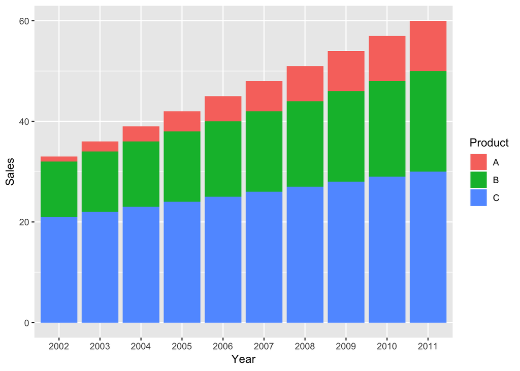

```r
ggplot(df) +
  geom_bar(aes(x=Year, y=Sales, fill = Product), stat="identity")
```